# Lake Erie Water Levels - A Time Series Analysis (Part 3/4)

> - 👟 Ready To Run!
> - 🚀 Data Exploration and Cleaning
> - 🤖 Machine Learning
> - ⏱️ Time Series Analysis

In this study, we will use continue to use [Lake Erie water level data](https://www.lre.usace.army.mil/Missions/Great-Lakes-Information/Great-Lakes-Information-2/Water-Level-Data/) to build **Seasonal ARIMA** models and forecast into the future.

# Table of Contents

In this notebook, we will:

- Read Lake Erie water level data and index it as a time series
- Discuss Stationarity of data
- Difference the data to make it stationary
  - Seasonal first order differencing
  - Seasonal and Non-seasonal first order differencing
- Use the ACF and PACF plots to decide AR term(s) and MA term(s) for SARIMA model
- Identify optimal SARIMA (p,d,q) x (P,D,Q) order using grid search
- Split the data
- Built and fit optimal SARIMA model
  - Obtain Predictions
- Evaluate Model performance
  - Plot predictions and calculate loss
- Forecast for 100 months into the future

# Part 3: Seasonal ARIMA Models

```python
# General Imports
import pandas as pd
import itertools
import time

# Imports for Visualization
import matplotlib.pyplot as plt
%matplotlib inline
import seaborn as sns

# Time Series Imports
from statsmodels.tsa.stattools import adfuller
from statsmodels.tsa.statespace.tools import diff
from statsmodels.graphics.tsaplots import plot_acf, plot_pacf
from statsmodels.tsa.statespace.sarimax import SARIMAX

# Ignore harmless warnings
import warnings
warnings.filterwarnings("ignore")
```

## Read and Preprocess Data

We’ll need to do some quick processing to read the data and convert it to have a time series index. We will read the Erie water level dataset from previous notebook.

```python
erie_data = pd.read_csv('erie_data')
erie_data.head()
```

|  | date | Erie | DES12 | TES12 |
| --- | --- | --- | --- | --- |
| 0 | 1918-01-01 | 173.90 | 173.881745 | 173.859612 |
| 1 | 1918-02-01 | 173.82 | 173.749419 | 173.880169 |
| 2 | 1918-03-01 | 174.01 | 174.160248 | 174.171219 |
| 3 | 1918-04-01 | 174.02 | 174.051395 | 174.139210 |
| 4 | 1918-05-01 | 173.98 | 173.950891 | 174.031776 |

```python
# Convert date to datetime column
erie_data['date'] = pd.to_datetime(erie_data['date'])
erie_data.dtypes
```

```
date     datetime64[ns]
Erie            float64
DES12           float64
TES12           float64
dtype: object
```

```python
# Set date as index
erie_data.set_index('date', inplace=True)
```

### Setting a DatetimeIndex Frequency

Note that our DatetimeIndex does not have a frequency. In order to build models, statsmodels needs to know the frequency of the data (whether it's daily, monthly etc.). Since observations occur at the start of each month, we'll use MS. A full list of time series offset aliases can be found [here](http://pandas.pydata.org/pandas-docs/stable/user_guide/timeseries.html#offset-aliases).

```python
# Set Frequency
erie_data.index.freq = 'MS'
erie_data.index
```

```
DatetimeIndex(['1918-01-01', '1918-02-01', '1918-03-01', '1918-04-01',
               '1918-05-01', '1918-06-01', '1918-07-01', '1918-08-01',
               '1918-09-01', '1918-10-01',
               ...
               '2019-03-01', '2019-04-01', '2019-05-01', '2019-06-01',
               '2019-07-01', '2019-08-01', '2019-09-01', '2019-10-01',
               '2019-11-01', '2019-12-01'],
              dtype='datetime64[ns]', name='date', length=1224, freq='MS')
```

## Seasonal ARIMA Models

*Represented as:* ARIMA (p,d,q) x [P,D,Q] S

A Seasonal ARIMA model [[1]](https://faculty.fuqua.duke.edu/~rnau/Decision411_2007/seasarim.htm) is formed by including additional seasonal terms in the ARIMA models. The seasonal part of the model consists of terms that are similar to the non-seasonal components of the model, but involve backshifts of the seasonal period.

In a Seasonal ARIMA model [[2]](https://online.stat.psu.edu/stat510/lesson/4/4.1) [5], seasonal AR and MA terms predict using data values and errors at times with lags that are multiples of S (the span of the seasonality). With monthly data (and S = 12), a seasonal first order autoregressive model would use $x_{t-12}$ to predict $x_{t}$.

A seasonal model is represented as ARIMA (p,d,q) x [P,D,Q] where P is the number of seasonal autoregressive (SAR) terms, D is the number of seasonal differences, Q is the number of seasonal moving average (SMA) terms.

The Non-seasonal components are: \begin{array}{l} \text { AR: } \phi(B)=1-\phi_{1} B-\ldots-\phi_{p} B^{p} \\ \text { MA: } \theta(B)=1+\theta_{1} B+\ldots+\theta_{q} B^{q} \end{array}

The Seasonal components are: \begin{array}{l} \text { Seasonal } A R: \Phi\left(B^{S}\right)=1-\Phi_{1} B^{S}-\ldots-\Phi_{P} B^{P S} \\ \text { Seasonal MA: } \Theta\left(B^{S}\right)=1+\Theta_{1} B^{S}+\ldots+\Theta_{Q} B^{Q S} \end{array}

We will follow this 7 step process to build, validate various Seasonal ARIMA models and forecast for future periods:

**Step 1** — Check stationarity: If a time series has a trend or seasonality component, it must be made stationary before we can use ARIMA to forecast.  
**Step 2** — Difference: If the time series is not stationary, it needs to be stationarized through differencing. Take the first difference (seasonal and non-seasonal), then check for stationarity.  
**Step 3** — Select AR and MA terms: Use the ACF and PACF to decide whether to include an AR term(s), MA term(s), or both.  
**Step 4** — Split the data into train and test sets  
**Step 5** — Build the model: Build the model and obtain predictions on test data.  
**Step 6** — Validate model: Compare the predicted values to the actuals in the test sample.  
**Step 7** — Forecasting: Retrain Model on full dataset and forecast for future time periods.

### Step 1 - Test for Stationarity

To effectively use ARIMA models, we need to understand if our data is stationary. A **stationary series** [[2]](https://people.duke.edu/~rnau/411diff.htm) has constant mean and variance over time. A time series that shows seasonality is *not* stationary.

A test for stationarity usually involves a hypothesis test, where the null hypothesis $H_0$ is that the series is *nonstationary*. The alternate hypothesis $H_1$ supports stationarity. To determine whether a series is stationary we can use the [augmented Dickey-Fuller Test](https://en.wikipedia.org/wiki/Augmented_Dickey-Fuller_test).

### Step 2 - Differencing

**Differencing** [[3]](https://otexts.com/fpp2/) is a method of transforming a non-stationary time series into a stationary one. When both trend and seasonality are present, we may need to apply both a non-seasonal first difference and a seasonal difference. A key step in identifying a seasonal model, is to determine whether or not a seasonal difference is needed, in addition to or perhaps instead of a non-seasonal difference. We must look at ACF and PACF plots for all possible combinations of 0 or 1 non-seasonal and seasonal differences [[4]](https://faculty.fuqua.duke.edu/~rnau/Decision411_2007/seasarim.htm).

We will plot first order difference plots along with ACF and PACF plots for both Seasonal and Non-seasonal differencing.

```python
# Difference the data
from statsmodels.tsa.statespace.tools import diff

# Non-Seasonal First Order Difference
diff1_ns = diff(erie_data['Erie'], k_diff=1)

# Seasonal First Order Difference
diff1_s = diff(erie_data['Erie'], k_seasonal_diff=1)

# Seasonal and Non-Seasonal First Order Difference
diff1_sns = diff(erie_data['Erie'], k_diff=1, k_seasonal_diff=1)
```

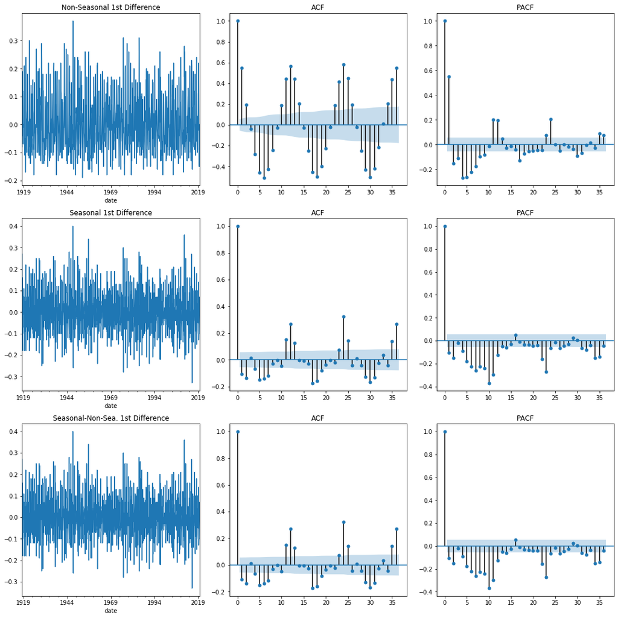

```python
# Run ACF and PACF plots of differenced data
from statsmodels.graphics.tsaplots import plot_acf, plot_pacf

fig, axes = plt.subplots(3,3, figsize=(15,15))

diff1_ns.plot(title='Non-Seasonal 1st Difference', ax=axes[0,0])
plot_acf(diff1_ns, lags=36, ax=axes[0,1], title='ACF')
plot_pacf(diff1_ns, lags=36, ax=axes[0,2], title='PACF')

diff1_s.plot(title='Seasonal 1st Difference', ax=axes[1,0])
plot_acf(diff1_s, lags=36, ax=axes[1,1], title='ACF')
plot_pacf(diff1_s, lags=36, ax=axes[1,2], title='PACF')

diff1_sns.plot(title='Seasonal-Non-Sea. 1st Difference', ax=axes[2,0])
plot_acf(diff1_sns, lags=36, ax=axes[2,1], title='ACF')
plot_pacf(diff1_sns, lags=36, ax=axes[2,2], title='PACF')

fig.tight_layout(pad=1.0)
plt.show()
```

> The plots above show `Non-seasonal`, `Seasonal`, `Seasonal and Non-Seasonal` First Order Differenced Plots. We can see that the plots ACF and PACF plots for `Seasonal First Order Difference` are very similar to `Seasonal and Non-Seasonal First Order Difference plots.

We will test both `Seasonal`, `Seasonal and Non-Seasonal` First Order Differenced data for Stationarity.

#### Test Stationarity for Seasonal First Order Differenced Data

We will use the function defined in `ARIMA Models` part of the study. This function creates more informative output from the test. We use **AIC** for the autolag because it penalizes higher order models over simpler models.

```python
# Define the adf-test function
from statsmodels.tsa.stattools import adfuller

def aug_dftest(series, title=''):

    print(f'Augmented Dickey Fuller Test for: {title}')
    result = adfuller(series.dropna(), autolag='AIC') # dropna() handles differenced data

    labels = ['ADF test statistic','p-value','# lags used','# observations']
    output = pd.Series(result[0:4], index=labels)
    for key, val in result[4].items():
        output[f'critical value ({key})'] = val

    print(output.to_string())

    if output[1] <= 0.05:
        print('Reject the Null hypothesis; Data is stationary')
    else:
        print('Fail to reject the Null hypothesis; Data is non-stationary')
```

```python
# Run the Test
aug_dftest(diff1_s, title='Seasonal First Order Differenced Data')
```

```
Augmented Dickey Fuller Test for: Seasonal First Order Differenced Data
ADF test statistic     -1.539824e+01
p-value                 3.241136e-28
# lags used             2.300000e+01
# observations          1.198000e+03
critical value (1%)    -3.435820e+00
critical value (5%)    -2.863956e+00
critical value (10%)   -2.568056e+00
Reject the Null hypothesis; Data is stationary
```

#### Test Stationarity for Seasonal and Non-Seasonal First Order Differenced Data

```python
# Run the Test
aug_dftest(diff1_sns, title='Seasonal First Order Differenced Data')
```

```
Augmented Dickey Fuller Test for: Seasonal First Order Differenced Data
ADF test statistic     -1.539824e+01
p-value                 3.241136e-28
# lags used             2.300000e+01
# observations          1.198000e+03
critical value (1%)    -3.435820e+00
critical value (5%)    -2.863956e+00
critical value (10%)   -2.568056e+00
Reject the Null hypothesis; Data is stationary
```

> Test results confirm that we reached stationarity after the first seasonal difference(D=1). Seasonal and Non-Seasonal First Order Differenced Data (d=1 and D=1) is also stationary.

A model with only Seasonal First Order Differencing will be a simpler model than a model with both Seasonal and Non-Seasonal First Order Differencing. *However, when both trend and seasonality are present, we may need to apply both a non-seasonal first difference and a seasonal difference*. We will look at `Seasonal`, `Seasonal and Non-Seasonal` First Order Differenced Plots in detail to get an optimal ARIMA (p,d,q) x (P,D,Q) Order.

### Determine ARIMA (p,d,q) x (P,D,Q) Order

#### Examine Seasonal First Order Difference Plots

ACF and PACF plots for both `Seasonal`, `Seasonal and Non-Seasonal` First Order Differenced data look exactly the same. Let's examine the Seasonal First Order Difference Plots of the data.

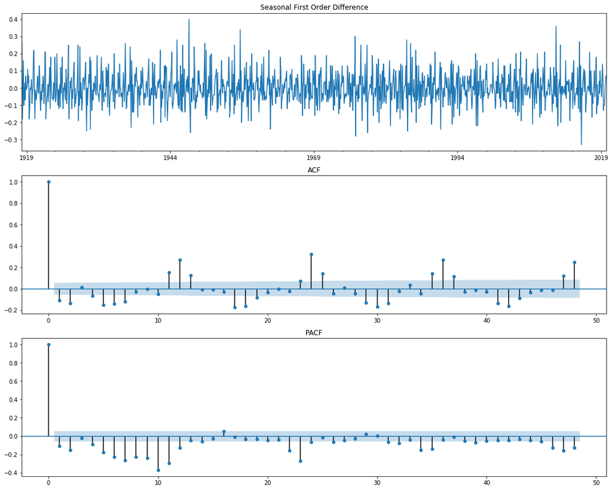

```python
# Run ACF and PACF plots of differenced data

fig, axes = plt.subplots(3,1, figsize=(15,12))

diff1_s.plot(title='Seasonal First Order Difference', ax=axes[0])
plot_acf(diff1_s, lags=48, ax=axes[1], title='ACF')
plot_pacf(diff1_s, lags=48, ax=axes[2], title='PACF')
axes[0].set(xlabel='')

fig.tight_layout(pad=1.0)
plt.show()
```

#### Examine Seasonal and Non-Seasonal First Order Difference Plots

Let's examine the Seasonal and Non-Seasonal First Order Difference Plots of the data.

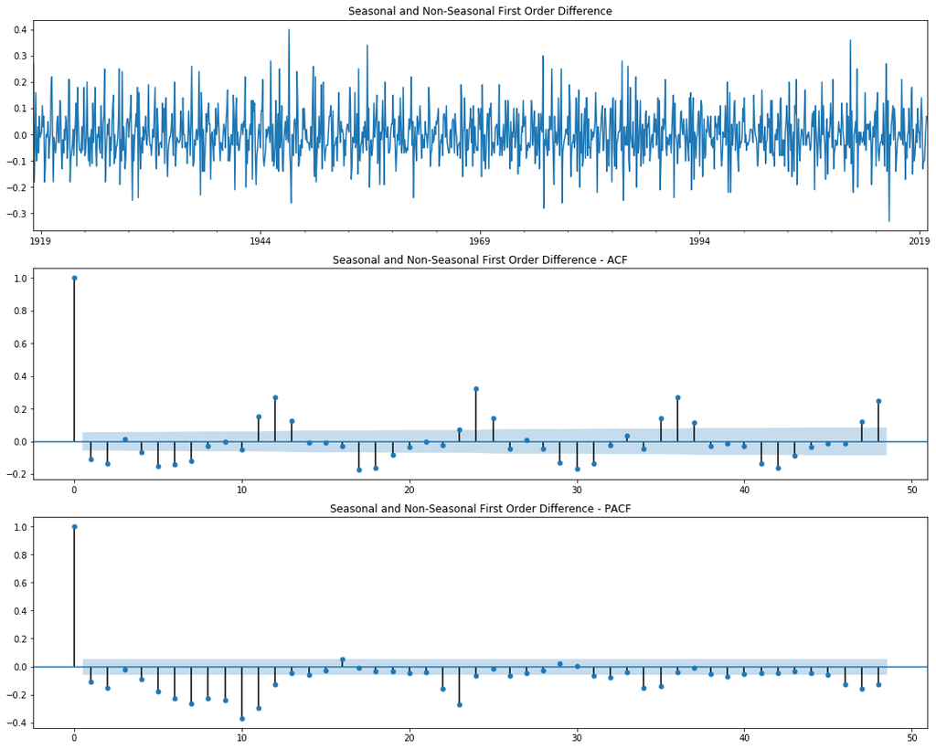

```python
# Run ACF and PACF plots of differenced data

fig, axes = plt.subplots(3,1, figsize=(15,12))

diff1_sns.plot(title='Seasonal and Non-Seasonal First Order Difference', ax=axes[0])
plot_acf(diff1_sns, lags=48, ax=axes[1], title='Seasonal and Non-Seasonal First Order Difference - ACF')
plot_pacf(diff1_sns, lags=48, ax=axes[2], title='Seasonal and Non-Seasonal First Order Difference - PACF')
axes[0].set(xlabel='')

fig.tight_layout(pad=1.0)
plt.show()
```

#### Evaluate ACF and PACF Plots

The plot above shows Seasonal, Seasonal and Non-Seasonal First Order Differenced data along with ACF and PACF plots.

Notice that:  
(a) ACF shows at lags 12, 24 etc., while the PACF cuts off after lag 12, 24.  
(b) There are some spikes in ACF and PACF plots at Non-seasonal lags 1 and 2 but they are not very significant.

The rules for identifying Seasonal AR and MA orders [[4]](https://faculty.fuqua.duke.edu/~rnau/Decision411_2007/seasarim.htm) [5] are as follows:

> *If the series has a strong and consistent seasonal pattern, then you should use an order of seasonal differencing--but never use more than one order of seasonal differencing or more than 2 orders of total differencing (seasonal+nonseasonal).*

> *If the autocorrelation at the seasonal period is positive, consider adding an SAR term to the model. If the autocorrelation at the seasonal period is negative, consider adding an SMA term to the model. Do not mix SAR and SMA terms in the same model, and avoid using more than one of either kind.*

#### Optimal ARIMA (p,d,q) x (P,D,Q) Order

From our analysis so far, we know that:

1. Lake Erie data is not stationary.
2. Seasonal First Order Differencing makes the data stationary.
3. We may need to apply both a non-seasonal first difference and a seasonal first difference

Our goal here is to find the optimal set of parameters (p,d,q) x (P,D,Q) that yield the best performance for our model.

We will define a function `seasonal_arima` that runs a grid search to iterate over the various Seasonal and Non-Seasonal orders with the following differencing scenarios:

1. Seasonal First Order Differencing (d=0, D=1)
2. Seasonal and Non-Seasonal First Order Differencing (d=1, D=1)

The function will evaluate all models created during the stepwise operation and list the best Seasonal ARIMA model for the differencing scenarios listed above along with their AICs. The recommended order is the one with the lowest [Akaike Information Criterion](https://en.wikipedia.org/wiki/Akaike_information_criterion) or AIC score. The AIC value will allow us to compare how well a model fits the data and takes into account the complexity of a model, so models that have a better fit while using fewer features will receive a better (lower) AIC score than similar models that utilize more features.

Note that results from all models can be printed by uncommenting the commented line of code in function definition.

##### Seasonal First Order Differenced Model (NS_Diff0_Model)

Non-Seasonal Difference (d=0) and Seasonal Difference (D=1)

```python
# Create a list of Non-Seasonal orders
p = q = range(0,3)
d = range(0, 1)
ns_diff0_pdq = list(itertools.product(p, d, q))
print(ns_diff0_pdq)
```

```
[(0, 0, 0), (0, 0, 1), (0, 0, 2), (1, 0, 0), (1, 0, 1), (1, 0, 2), (2, 0, 0), (2, 0, 1), (2, 0, 2)]
```

```python
# Create a list of Seasonal orders
seasonal_pdq = [(x[0], 1, x[2], 12) for x in ns_diff0_pdq]
print(seasonal_pdq)
```

```
[(0, 1, 0, 12), (0, 1, 1, 12), (0, 1, 2, 12), (1, 1, 0, 12), (1, 1, 1, 12), (1, 1, 2, 12), (2, 1, 0, 12), (2, 1, 1, 12), (2, 1, 2, 12)]
```

```python
# Function to iterate over Seasonal and Non-Seasonal orders
from statsmodels.tsa.statespace.sarimax import SARIMAX

def seasonal_arima(data, pdq):
    model_order = [0,0]
    min_aic = 1000
    for param in pdq:
        for seas_param in seasonal_pdq:
            try:
                model = SARIMAX(data, order=param, seasonal_order=seas_param)
                model_fit = model.fit(solver='nm')
                aic = model_fit.aic
#                 print(f'SARIMA{param}x{seas_param} - AIC: {aic}')
                if aic < min_aic:
                    min_aic = aic
                    model_order[0] = param
                    model_order[1] = seas_param

            except:
                continue

#   Print model with lowest AIC
    print('---------------------')
    print('MODEL WITH LOWEST AIC')
    print('---------------------')
    print(f'SARIMA{model_order[0]}x{model_order[1]} - AIC: {min_aic}')
```

Based on the number of Non-Seasonal (9) and Seasonal (9) orders this function will iterate over 81 (9x9) different models to return a model with the lowest AIC.

```python
%%time
# Apply function on Erie data
seasonal_arima(erie_data['Erie'], ns_diff0_pdq)
```

```
---------------------
MODEL WITH LOWEST AIC
---------------------
SARIMA(1, 0, 1)x(0, 1, 1, 12) - AIC: -3247.453338976233
CPU times: user 9min 8s, sys: 4.26 s, total: 9min 13s
Wall time: 6min 25s
```

##### Seasonal and Non-Seasonal First Order Differenced Model (NS_Diff1_Model)

Non-Seasonal Difference (d=1) and Seasonal Difference (D=1)

```python
# Create a list of Non-Seasonal orders
p = q = range(0, 3)
d = range(1, 2)
ns_diff1_pdq = list(itertools.product(p, d, q))
print(ns_diff1_pdq)
```

```
[(0, 1, 0), (0, 1, 1), (0, 1, 2), (1, 1, 0), (1, 1, 1), (1, 1, 2), (2, 1, 0), (2, 1, 1), (2, 1, 2)]
```

```python
# Create a list of Seasonal orders
seasonal_pdq = [(x[0], 1, x[2], 12) for x in ns_diff0_pdq]
print(seasonal_pdq)
```

```
[(0, 1, 0, 12), (0, 1, 1, 12), (0, 1, 2, 12), (1, 1, 0, 12), (1, 1, 1, 12), (1, 1, 2, 12), (2, 1, 0, 12), (2, 1, 1, 12), (2, 1, 2, 12)]
```

Based on the number of Non-Seasonal (9) and Seasonal (9) orders this function will iterate over 81 (9x9) different models to return a model with the lowest AIC.

```python
%%time
# Apply function on Erie data
seasonal_arima(erie_data['Erie'], ns_diff1_pdq)
```

```
---------------------
MODEL WITH LOWEST AIC
---------------------
SARIMA(2, 1, 1)x(0, 1, 2, 12) - AIC: -3236.415833446461
CPU times: user 9min 18s, sys: 3.18 s, total: 9min 21s
Wall time: 6min 23s
```

The results above show that the best model with **Non-Seasonal Difference (d=0) and Seasonal Difference (D=1)** is an `ARIMA (1, 0, 1) (0, 1, 1, 12)` model (**NS_Diff0_Model**) with an AIC of `-3247.453`. This model has a lower AIC than the **Non-Seasonal Difference (d=1) and Seasonal Difference (D=1)** `ARIMA (2, 1, 1), (0, 1, 2, 12)` model (**NS_Diff1_Model**) with an AIC of `-3236.416`.

As mentioned above, the recommended order is the one with the lowest [Akaike Information Criterion](https://en.wikipedia.org/wiki/Akaike_information_criterion) or AIC score.

AlC for **NS_Diff0_Model** is lower and it is a simpler model than **NS_Diff1_Model**. However, we will fit both models on our data to see which one fits better.

### Step 4 - Split the Data

We will spilt the data into train and test sets.

```python
# Split the data

# TRAIN Data
train_data = erie_data.iloc[:1124]
train_data = train_data.astype('float64') # casting as float to avoid errors in prediction

# TEST Data
test_data = erie_data.iloc[1124:]
test_data = test_data.astype('float64')
```

### Step 5 - Build the Model

We will build both SARIMA (1, 0, 1)x(0, 1, 1, 12) model and SARIMA (2, 1, 1)x(0, 1, 2, 12) model.

#### Seasonal ARIMA (1,0,1) (0,1,1,12) (`NS_Diff0_Model`)

We will build a **Seasonal ARIMA (1,0,1) (0,1,1,12)** model on the training data and fit the model. This model has Non-Seasonal Difference (d=0) and Seasonal Difference (D=1).

```python
# Build NS_Diff0_Model
NS_Diff0_Model = SARIMAX(train_data['Erie'], order=(1,0,1), seasonal_order=(0,1,1,12))
NS_Diff0_results = NS_Diff0_Model.fit(solver='nm')
NS_Diff0_results.summary()
```

SARIMAX Results

| Dep. Variable: | Erie | No. Observations: | 1124 |
| --- | --- | --- | --- |
| Model: | SARIMAX(1, 0, 1)x(0, 1, 1, 12) | Log Likelihood | 1500.318 |
| Date: | Sat, 29 Aug 2020 | AIC | -2992.635 |
| Time: | 14:12:55 | BIC | -2972.580 |
| Sample: | 01-01-1918 | HQIC | -2985.052 |
|  | - 08-01-2011 |  |  |
| Covariance Type: | opg |  |  |

|  | coef | std err | z | P>\|z\| | [0.025 | 0.975] |
| --- | --- | --- | --- | --- | --- | --- |
| ar.L1 | 0.9656 | 0.008 | 115.865 | 0.000 | 0.949 | 0.982 |
| ma.L1 | 0.2744 | 0.028 | 9.912 | 0.000 | 0.220 | 0.329 |
| ma.S.L12 | -0.9538 | 0.011 | -86.315 | 0.000 | -0.975 | -0.932 |
| sigma2 | 0.0038 | 0.000 | 30.850 | 0.000 | 0.004 | 0.004 |

| Ljung-Box (Q): | 31.84 | Jarque-Bera (JB): | 203.64 |
| --- | --- | --- | --- |
| Prob(Q): | 0.82 | Prob(JB): | 0.00 |
| Heteroskedasticity (H): | 0.99 | Skew: | 0.76 |
| Prob(H) (two-sided): | 0.91 | Kurtosis: | 4.44 |

Warnings:  
[1] Covariance matrix calculated using the outer product of gradients (complex-step).

##### Obtain Predictions

```python
start = len(train_data)
end = len(train_data) + len(test_data)-1

NS_Diff0_predictions = NS_Diff0_results.predict(start=start, end=end,
                                                dynamic=False, typ='levels')
```

Passing `dynamic=False` means that forecasts at each point are generated using the full history up to that point (all lagged values). Passing `typ='levels'` predicts the levels of the original endogenous variables. If we'd used the default `typ='linear'` we would have seen linear predictions in terms of the differenced endogenous variables.

For more information on these arguments, check `statsmodels` documentation [here](https://www.statsmodels.org/stable/generated/statsmodels.tsa.arima_model.ARIMAResults.predict.html).

Let’s reorganize this set of predictions by creating a dataframe that contains our model predictions and then concatenating that with the test data.

```python
NS_Diff0 = pd.DataFrame(NS_Diff0_predictions.values,
                       index = test_data.index,
                       columns = ['NS_Diff0_predictions'])
test_data = pd.concat([test_data, NS_Diff0], axis=1)
test_data[['Erie', 'NS_Diff0_predictions']].head()
```

| date | Erie | NS_Diff0_predictions |
| --- | --- | --- |
| 2011-09-01 | 174.30 | 174.281175 |
| 2011-10-01 | 174.27 | 174.179219 |
| 2011-11-01 | 174.21 | 174.106513 |
| 2011-12-01 | 174.40 | 174.106436 |
| 2012-01-01 | 174.39 | 174.129626 |

#### Seasonal ARIMA (2,1,1) (0,1,2,12) (`NS_Diff1_Model`)

We will build a **Seasonal ARIMA (2,1,1) (0,1,2,12)** model on the training data and fit the model. This model has Non-Seasonal Difference (d=1) and Seasonal Difference (D=1).

```python
# Build NS_Diff1_Model
NS_Diff1_Model = SARIMAX(train_data['Erie'], order=(2,1,1), seasonal_order=(0,1,2,12))
NS_Diff1_results = NS_Diff1_Model.fit(solver='nm')
NS_Diff1_results.summary()
```

SARIMAX Results

| Dep. Variable: | Erie | No. Observations: | 1124 |
| --- | --- | --- | --- |
| Model: | SARIMAX(2, 1, 1)x(0, 1, [1, 2], 12) | Log Likelihood | 1490.434 |
| Date: | Sat, 29 Aug 2020 | AIC | -2968.869 |
| Time: | 14:13:16 | BIC | -2938.791 |
| Sample: | 01-01-1918 | HQIC | -2957.496 |
|  | - 08-01-2011 |  |  |
| Covariance Type: | opg |  |  |

|  | coef | std err | z | P>\|z\| | [0.025 | 0.975] |
| --- | --- | --- | --- | --- | --- | --- |
| ar.L1 | 0.3940 | 0.338 | 1.165 | 0.244 | -0.269 | 1.057 |
| ar.L2 | -0.1147 | 0.091 | -1.262 | 0.207 | -0.293 | 0.063 |
| ma.L1 | -0.1186 | 0.338 | -0.351 | 0.725 | -0.780 | 0.543 |
| ma.S.L12 | -0.9746 | 0.028 | -34.667 | 0.000 | -1.030 | -0.919 |
| ma.S.L24 | 0.0114 | 0.028 | 0.406 | 0.685 | -0.044 | 0.066 |
| sigma2 | 0.0039 | 0.000 | 29.963 | 0.000 | 0.004 | 0.004 |

| Ljung-Box (Q): | 38.55 | Jarque-Bera (JB): | 176.39 |
| --- | --- | --- | --- |
| Prob(Q): | 0.54 | Prob(JB): | 0.00 |
| Heteroskedasticity (H): | 1.00 | Skew: | 0.70 |
| Prob(H) (two-sided): | 1.00 | Kurtosis: | 4.36 |

Warnings:  
[1] Covariance matrix calculated using the outer product of gradients (complex-step).

##### Obtain Predictions

```python
start = len(train_data)
end = len(train_data) + len(test_data)-1

NS_Diff1_predictions = NS_Diff1_results.predict(start=start, end=end,
                                                dynamic=False, typ='levels')
```

Passing `dynamic=False` means that forecasts at each point are generated using the full history up to that point (all lagged values). Passing `typ='levels'` predicts the levels of the original endogenous variables. If we'd used the default `typ='linear'` we would have seen linear predictions in terms of the differenced endogenous variables.

For more information on these arguments, check `statsmodels` documentation [here](https://www.statsmodels.org/stable/generated/statsmodels.tsa.arima_model.ARIMAResults.predict.html).

Let’s reorganize this set of predictions by creating a dataframe that contains our model predictions and then concatenating that with the test data.

```python
NS_Diff1 = pd.DataFrame(NS_Diff1_predictions.values,
                       index = test_data.index,
                       columns = ['NS_Diff1_predictions'])
test_data = pd.concat([test_data, NS_Diff1], axis=1)
test_data[['Erie', 'NS_Diff1_predictions']].head()
```

| date | Erie | NS_Diff1_predictions |
| --- | --- | --- |
| 2011-09-01 | 174.30 | 174.282751 |
| 2011-10-01 | 174.27 | 174.183662 |
| 2011-11-01 | 174.21 | 174.114293 |
| 2011-12-01 | 174.40 | 174.115091 |
| 2012-01-01 | 174.39 | 174.136733 |